# 02 - Creating a custom and unique visualization

## **Visualizing aspects of data with facets**

**1. Visualizing aspects of data with facets**

Welcome to the second chapter of this course. In this chapter, you are going to explore a less conventional form of visualization, the dot plot. But before that, we are going to quickly revise faceting – a nice ggplot-way of looking at different aspects of a data set.

**2. The facet_grid() function**

You may already know about the facet_wrap function from previous courses. Here, you’ll learn about the facet_grid function. Its advantage is that you can determine whether you want to order the facets horizontally or vertically. For that, the first argument given to the function is slightly different than for facet_wrap. It always takes a formula, which is denoted by the tilde in the middle of the formula. On the right-hand side you specify what variable will determine the columns of the plot, while the left-hand side variable will determine the rows of the plot. If you want to facet by one variable only, use the dot to indicate that there should be no faceting on this dimension.

**3. The facet_grid() function**

Actually, the facet_grid call with . ~ year gives identical results as facet_wrap with the same formula. Notice, however, that the dot needs to be removed from the formula in facet_wrap – we usually call this a one-sided formula, while facet_grid takes a two-sided formula.

**4. A faceted scatter plot**

**5. Styling faceted plots**

Another reason we are revisiting faceting here is that there are some specific theme options for faceted plots, like strip.background and strip.text. They can be used to style the small titles that are given to each facet, here displaying the respective year.

**6. Defining your own theme function**

**7. Let’s practice!**

Let’s do it!

### **Prepare the data set for the faceted plot**

You’re now going to prepare your data set for producing the faceted scatter plot in the next exercise, as mentioned in the video. For this, the data set needs to contain only the years §1996 and 2006, because your plot will only have two facets. `ilo_data` has been pre-loaded for you.

**Instructions**

- Use `filter()` to only retain the years 1996 and 2006 in the data set.
- Use the OR operator in your `filter()` function call.

```r
# Filter ilo_data to retain the years 1996 and 2006
ilo_data <- ilo_data %>%
  filter(year == 1996 | year == 2006)
```

### **Add facets to the plot**

Here, you’ll leverage `facet_grid()` to add horizontal facets for 1996 and 2006 each, as detailed in the video.

When using `facet_grid()`, it is good practice to specify the facet formula with a named argument: `facets = ...`. This helps to avoid confusion since the `facet_grid()` function takes many other arguments.

**Instructions**

- Use `facet_grid()` with the right formula to generate two separate scatter plots that are arranged horizontally.
- The left plot should show the data for the year 1996 while the year 2006 should be shown on the right side.

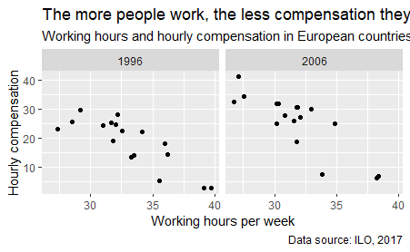

```r
# Again, you save the plot object into a variable so you can save typing later on
ilo_plot <- ggplot(ilo_data, aes(x = working_hours, y = hourly_compensation)) +
  geom_point() +
   labs(
    x = "Working hours per week",
    y = "Hourly compensation",
    title = "The more people work, the less compensation they seem to receive",
    subtitle = "Working hours and hourly compensation in European countries, 2006",
    caption = "Data source: ILO, 2017"
  ) +
  # Add facets here
  facet_grid(facet = . ~ year)

ilo_plot
```

### **Define your own theme function**

In the video you saw how a lot of typing can be saved by replacing code chunks with function calls. You saw how a function is usually defined, now you will apply this knowledge in order to make your previous two `theme()` calls reusable.

**Instructions**

- Using your new knowledge about function definitions, create a function named `theme_ilo()` that encapsulates your theme settings.
- The function body should contain both `theme()` calls that you would normally apply directly to a plot object: `theme_minimal() +` your customized `theme()` function.
- Copy what you did before into this `theme_ilo()` function, using the `theme()` settings provided in the sample code.

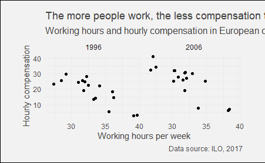

```r
# For a starter, let's look at what you did before: adding various theme calls to your plot object
ilo_plot +
  theme_minimal() +
  theme(
    text = element_text(family = "Bookman", color = "gray25"),
    plot.subtitle = element_text(size = 12),
    plot.caption = element_text(color = "gray30"),
    plot.background = element_rect(fill = "gray95"),
    plot.margin = unit(c(5, 10, 5, 10), units = "mm")
  )
```

```r
# Define your own theme function below
theme_ilo <- function() {
    theme_minimal() +
  theme(
    text = element_text(family = "Bookman", color = "gray25"),
    plot.subtitle = element_text(size = 12),
    plot.caption = element_text(color = "gray30"),
    plot.background = element_rect(fill = "gray95"),
    plot.margin = unit(c(5, 10, 5, 10), units = "mm")
  )
}
```

### **Apply the new theme function to the plot**

Once you have created your own `theme_ilo()` function, it is time to apply it to a plot object. In the video you saw that `theme()` calls can be chained. You’re going to make use of this and add another `theme()` call to adjust some peculiarities of the faceted plot.

**Instructions**

- From now on, you can just add `theme_ilo()` to any plot object you wish. Try it out! Overwrite the `ilo_plot` variable so `theme_ilo()` is applied permanently.
- Combine your custom theme function with even further `theme()` calls to flexibly adjust settings for advanced plots.
  - In order to do that, add another `theme()` call after the `theme_ilo()` call.
  - Change the background fill of the facet labels to `"gray60"` and their color to `"gray95"`, using the `strip.background` argument.
  - Change the color of the facet labels to `"white"`.

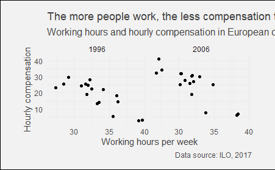

```r
# Apply your theme function (dont't forget to call it with parentheses!)
ilo_plot <- ilo_plot +
  theme_ilo()

# Examine ilo_plot
ilo_plot
```

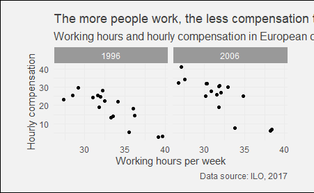

```r
ilo_plot +
  # Add another theme call
  theme(
    # Change the background fill and color
    strip.background = element_rect(fill = 'gray60', color = 'gray95'),
    # Change the color of the text
    strip.text = element_text(color = 'white')
  )
```

## **A custom plot to emphasize change**

**1. A custom plot to emphasize change**

Great job! From the plot you just produced we see that there was a negative correlation between working hours and hourly compensation also in 1996.

However, some countries seem to have shifted their position. In 2006, there are more countries with higher hourly compensation, and also more with less weekly working hours. From this scatter plot, we can’t really tell which countries have made the biggest shift.

**3. The dot plot**

**4. Dot plots with ggplot2**

**5. The geom_path() function**

geom_path is useful for creating plots based on fundamental geometric elements, such as lines. If you look at the help for geom_path, it tells you that it connects the observations in a data set in the order in which they appear. Let’s have a look at your current data set. In the first exercise of this chapter, you filtered it to only contain the years 1996 and 2006. If you order that data frame by country, you see that there are two rows for each country, representing both years. 1996 always comes before 2006, so geom_path will draw a path from 1996 to 2006, as these years appear in the data set.

**6. Dot plots with `ggplot2`: the `geom_path()` function**

geom_path requires the x- and y-aesthetic to be set. Both can be numeric variables, so geom_path will draw a path in the two-dimensional plane. However, one of both can also be a factor variable. If you specify a numeric variable for the x-aesthetic, and a factor for the y-aesthetic, geom_path will draw a single path for each value in the y-aesthetic, that is, for each value of the factor variable. Also, you can add an arrow to each path, using the arrow argument outside the aesthetics function. The arrow argument in turn takes an arrow function call, where you can specify the type of the arrow head and other settings. The arrow will be placed at the last section of your path and thus point into the same direction the path was drawn.

**7. Let’s try out geom_path!**

This may sound a bit theoretical, so let’s look at a concrete example and build your first iteration of the dot plot.

### **A basic dot plot**

As shown in the video, use only `geom_path()` to create the basic structure of the dot plot.

**Instructions**

- Create a new ggplot object which takes `ilo_data` as data set.
- Add a `geom_path()` geometry where the weekly working hours are mapped to the x-axis and countries to the y-axis.

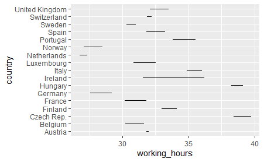

```r
# Create the dot plot
ilo_data %>%
  ggplot() +
  geom_path(aes(x = working_hours, y = country))
```

Now that looks different from what you’ve seen – the lines show the change between 1996 and 2006 for each direction. Yet, readers don’t know the position of these years in the plot, that’s why you’ll add arrows to the paths.

### **Add arrows to the lines in the plot**

Instead of labeling years, use the `arrow` argument of the `geom_path()` call to show the direction of change. The arrows will point from 1996 to 2006, because that’s how the data set is ordered. The `arrow()` function takes two arguments: The first is `length`, which can be specified with a `unit()` call, which you might remember from previous exercises. The second is `type` which defines how the arrow head will look.

**Instructions**

- Use the `arrow` argument and an `arrow()` function call to add arrows to each line.
- For the arrows, specify a `length` of `1.5` `"mm"` (with a unit() call) and a `type` of `"closed"`.

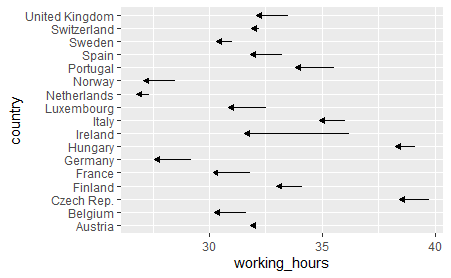

```r
ggplot(ilo_data) +
  geom_path(aes(x = working_hours, y = country),
  # Add an arrow to each path
  arrow = arrow(length = unit(1.5, "mm"), type = "closed"))
```

Now it becomes implicitly clear that all the countries have seen a decrease in weekly working hours since 1996, because the arrows are always pointing to the left.

### **Add some labels to each country**

A nice thing that can be added to plots are annotations or labels, so readers see the value of each data point displayed in the plot panel. This often makes axes obsolete, an advantage you’re going to use in the last exercise of this chapter. These labels are usually added with `geom_text()` or `geom_label()`. The latter adds a background to each label, which is not needed here.

**Instructions**

- Label both points on the line with their respective working hours value. Use the `geom_text()` function for this, with the x- and y-aesthetic identical to the one in the `geom_path()` call.
- Specify the `working_hours` variable for the `label` argument. Round `working_hours` to one digit after the decimal point.

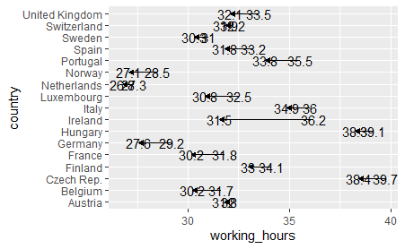

```r
ggplot(ilo_data) +
  geom_path(aes(x = working_hours, y = country),
            arrow = arrow(length = unit(1.5, "mm"), type = "closed")) +
  # Add a geom_text() geometry
  geom_text(
          aes(x = working_hours, y = country,
              label = round(working_hours, 1))
        )
```

Cool, now the x-axis is obsolete and can be removed in the remainder of this chapter. The labels are still kind of misplaced…

## **Polishing the dot plot**

**1. Polishing the dot plot**

Great work. You’ve explored a new type of visualization in ggplot2. Actually, building the plot is quite easy, you only used the geom_path geometry for the lines with arrows, and the geom_text geometry to add labels.

But still, by just looking at the plot you can probably tell that it’s far from perfect. Obviously, the labels should be better placed – now, they overlap with the lines. Also, it’s hard to compare countries with each other because they are ordered alphabetically at the moment. It’s not straightforward to tell which country still has the highest weekly working hours. The solution lies in factor levels.

**3. Factor levels**

Factors are used to describe categorical variables with a fixed and known set of **levels**. The order of these levels usually determines the order of appearance in ggplot2 graphics. If you look at the country variable by typing ilo_data$country in the R console, you get its values but also its levels, listed in the actual order.

**4. Reordering factors with the forcats package**

Wrangling factors and factor levels sometimes can be a bit tedious. But there’s a special package for making this easier, called forcats. It is part of the Tidyverse but needs to be loaded explicitly with a library call. It has a couple of useful functions, here’s some of them.

1 Learn more at tidyverse.org (http://forcats.tidyverse.org/)

**5. The fct_reorder function**

With the fct_reorder function, we can reorder factors in a data-driven way, based on the ranks of another variable in the data set. Let’s have a look at our current data set again. As you know, there are two rows per country, one for each year. If we want to reorder the countries based on the value of working hours we can decide whether to take the value for 1996 or the value for 2006 for reordering. With the fct_reorder function, though, we can also specify a custom summary function as the last argument. This function is applied to all values of the same factor level, that is, of the same country. If we specify the mean function as the third argument to the fct_reorder function, for instance, the mean weekly working hours of both years is computed for each country, and then the countries are reordered according to this mean value. As you can see, the levels are now different, the list starts with the Netherlands, which has the lowest mean weekly working hours.

**6. The fct_reorder function**

Let’s have a detailed look at this again. In the fct_reorder function, we first need to specify the factor variable to reorder, then another variable whose ranking dictates the order of levels, and then a summary function. This summary function is then applied to each value for every factor level. These values are given as vector arguments to the summary function, so for Austria, the mean of 31.99 and 31.82 is calculated, and so forth.

**7. Nudging labels with hjust and vjust**

One problem remains: The working hour labels for both years still overlap with the arrows. In order to solve this we can make use of the hjust and vjust aesthetics for the geom_text geometry. If you want to nudge labels horizontally, you use the hjust aesthetic, which takes values from 0 to 1, but values outside this range are also possible. For our plot, I found 1.4 and -0.4 to be good values. Since hjust is an aesthetic, its value can be data-driven. Here, we use different values for the years 1996 and 2006, respectively. The ifelse function is perfect for that - if the year is 2006, use 1.4 as value, if not, use -0.4.

**8. Let’s practice!**

That was a lot. Once you try it out yourself it will be easier for you to grasp!

### **Reordering elements in the plot**

As shown in the video, use `mutate()` and `fct_reorder()` to change the factor level ordering of a variable.

**Instructions**

- Use `fct_reorder()` in the `forcats` package to reorder the `country` factor variable by weekly working hours in the year 2006.
  - To do that, specify the correct summary function as the third argument of `fct_reorder`. It should arrange the country factor levels by the last element in the `working_hours` variable.
  - In order to do the above, you first need to `arrange()` the data set by year – so 1996 is always first in each country group and 2006 is always last.

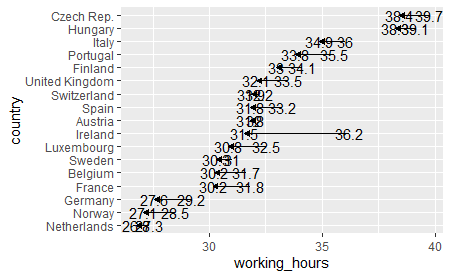

```r
library(forcats)

# Reorder country factor levels
ilo_data <- ilo_data %>%
  # Arrange data frame
  arrange(year) %>%
  # Reorder countries by working hours in 2006
  mutate(country = fct_reorder(country,
                               working_hours,
                               last))

# Plot again
ggplot(ilo_data) +
  geom_path(aes(x = working_hours, y = country),
            arrow = arrow(length = unit(1.5, "mm"), type = "closed")) +
    geom_text(
          aes(x = working_hours,
              y = country,
              label = round(working_hours, 1))
          )
```

now, countries appear in a defined order, which makes them way easier to compare to each other. But the labels still need fixing…

### **Correct ugly label positions**

The labels still kind of overlap with the lines in the dot plot. Use a conditional `hjust` aesthetic in order to better place them, and change their appearance.

**Instructions**

- Give the `hjust` aesthetic in the `geom_text()` function call a value of `1.4`, if it concerns the label for the year `"2006"`, and `-0.4` if not. Use the `ifelse()` function for this.
- Change font size, family and color to `3`, `"Bookman"` and `"gray25"` respectively, also in the `geom_text()` call, but outside of the `aes()` function since these values are not data-driven.

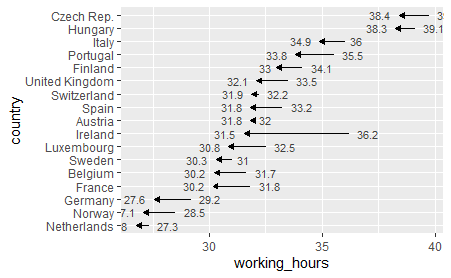

```r
# Save plot into an object for reuse
ilo_dot_plot <- ggplot(ilo_data) +
  geom_path(aes(x = working_hours, y = country),
            arrow = arrow(length = unit(1.5, "mm"), type = "closed")) +
    # Specify the hjust aesthetic with a conditional value
    geom_text(
          aes(x = working_hours,
              y = country,
              label = round(working_hours, 1),
              hjust = ifelse(year == 2006, 1.4, -0.4)
            ),
          # Change the appearance of the text
          size = 3,
          family = "Bookman",
          color = "gray25"
          )

ilo_dot_plot
```

This problem has been solved. But now you’ve got another one: The labels on the very left and the very right overlap with the margins of the plot.

## **Finalizing the plot for different audiences and devices**

**1. Finalizing the plot for different audiences and devices**

You’re almost done! In this last section of the second chapter, you’re going to finalize your dot plot, apply your custom theme and make it fit for different audiences and devices.

Let’s have a look at the current state of your plot. The labels are now shifted so they don’t overlap with the arrows anymore, and they already have the right font family, color and size. They will look great together with your custom theme you are going to apply shortly. However, you’ve introduced another problem. The labels now overlap with the plot panel borders on the left and right side of the panel. In the following exercise, you are going to change the viewport in order to solve this problem.

**3. coord_cartesian vs. xlim / ylim**

There are basically two ways you can change the viewport of your plot - that is, to zoom in or out, or to change the position of the viewport. On one hand there’s the possibility of adding xlim and ylim arguments to the coord_cartesian function, which is the default coordinate system for ggplot objects. Here, we set the x dimension to go from 0 to 100 and the y dimension to go from 10 to 20, even though our data might not span this range. Then there’s also the possibility to directly call the xlim and ylim functions and add them to the ggplot_object. Does this give the same results?

**4. coord_cartesian vs. xlim / ylim**

Almost! The difference is subtle but important. Using coord_cartesian retains all data points in the plot, while using xlim or ylim actually clips the data and removes points outside of the viewport. This may result in ugly artifacts. So, I would argue it’s generally better to use coord_cartesian.

1 Taken from RStudio Data Visualization Cheat Sheet (https://github.com/rstudio/cheatsheets/raw/master/data-visualization-2.1.pdf)

**6. Desktop vs. Mobile audiences**

**7. Let’s produce these plots!**

Let’s do this!

### **Change the viewport so labels don’t overlap with plot border**

Use a function introduced in the previous video to change the viewport of the plotting area. Also apply your custom theme.

**Instructions**

- Fix the label overlap problem by resetting the x-limits of the cartesian coordinate system to `25` and `41`. Make sure to use a function that doesn’t clip the geometries in your plot.
- Remember your custom `theme_ilo()` function? Apply it to the plot.

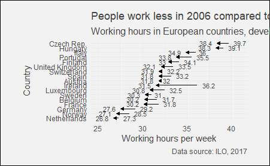

```r
# Reuse ilo_dot_plot
ilo_dot_plot <- ilo_dot_plot +
  # Add labels to the plot
  labs(
    x = "Working hours per week",
    y = "Country",
    title = "People work less in 2006 compared to 1996",
    subtitle = "Working hours in European countries, development since 1996",
    caption = "Data source: ILO, 2017"
  ) +
  # Apply your theme
  theme_ilo() +
  # Change the viewport
  coord_cartesian(xlim = c(25, 41))

# View the plot
ilo_dot_plot
```

The plot looks totally different with your theme applied, and the labels fit nicely.

### **Optimizing the plot for mobile devices**

The x-axis title is already quite superfluous because you’ve added labels for both years. You’ll now add country labels to the plot, so all of the axes can be removed.

In this exercise, you’re going to encounter something that is probably new to you: New data sets can be given to single geometries like `geom_text()`, so these geometries don’t use the data set given to the initial `ggplot()` call. In this exercise, you are going to need this because you only want to add one label to each arrow. If you were to use the original data set `ilo_data`, two labels would be added because there are two observations for each country in the data set, one for 1996 and one for 2006.

**Instructions**

- A new data set `median_working_hours` was created so there will only be one label per country. Have a look at the structure of it with `str()`.
- Use `median_working_hours` as the data argument in a new `geom_text()` call, in order to add labels for each country.
- Correctly specify the required aesthetics for `geom_text()`: `x` and `label` which should point to the right variable in the `median_working_hours` data set.
- Remove all the axes and the background grid by specifying the `element_blank()` function for all the `axis.` and the `panel.grid` arguments in the custom `theme()` call.
- After running the final code, resize the plot window on the right to simulate a mobile device screen in portrait mode (narrow and tall) – all labels will fit the plot viewport.

```r
# Compute temporary data set for optimal label placement
median_working_hours <- ilo_data %>%
  group_by(country) %>%
  summarize(median_working_hours_per_country = median(working_hours)) %>%
  ungroup()

# Have a look at the structure of this data set
str(median_working_hours)
```

```
tibble [17 x 2] (S3: tbl_df/tbl/data.frame)
 $ country                         : Factor w/ 30 levels "Netherlands",..: 1 2 3 4 5 6 7 8 9 10 ...
 $ median_working_hours_per_country: num [1:17] 27 27.8 28.4 31 30.9 ...
```

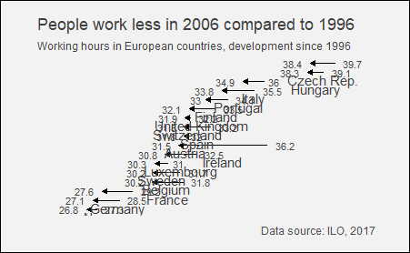

```r
ilo_dot_plot +
  # Add label for country
  geom_text(data = median_working_hours,
            aes(y = country,
                x = median_working_hours_per_country,
                label = country),
            vjust = 2,
            family = "Bookman",
            color = "gray25") +
  # Remove axes and grids
  theme(
    axis.ticks = element_blank(),
    axis.title = element_blank(),
    axis.text = element_blank(),
    panel.grid = element_blank(),
    # Also, let's reduce the font size of the subtitle
    plot.subtitle = element_text(size = 9)
  )
```

Now the plot is stripped of all superfluous elements. You’ll now embed it into a so-called RMarkdown report! PS: Remember to resize the plot window in order to see what it would look like on a mobile screen.